# R Notebook

```r
library(broom)
```

The file project_management.csv contains data sampled from the recent work schedule of a small construction company. Column estimated_length contains the estimated length of a building job in days, while column actual_length contains the actual recorded length of the job in days.

We are interested in determining the accuracy of the job estimations made by the company using simple linear regression, so we will eventually want to run a simple linear regression using actual_length as the dependent variable, and estimated_length as the independent variable.

# Load the data into a dataframe project

```r
job_length <- read_csv("data/project_management.csv") %>% clean_names()
```

# Plot the data, taking estimated_length as the independent variable and actual_length as the dependent variable.

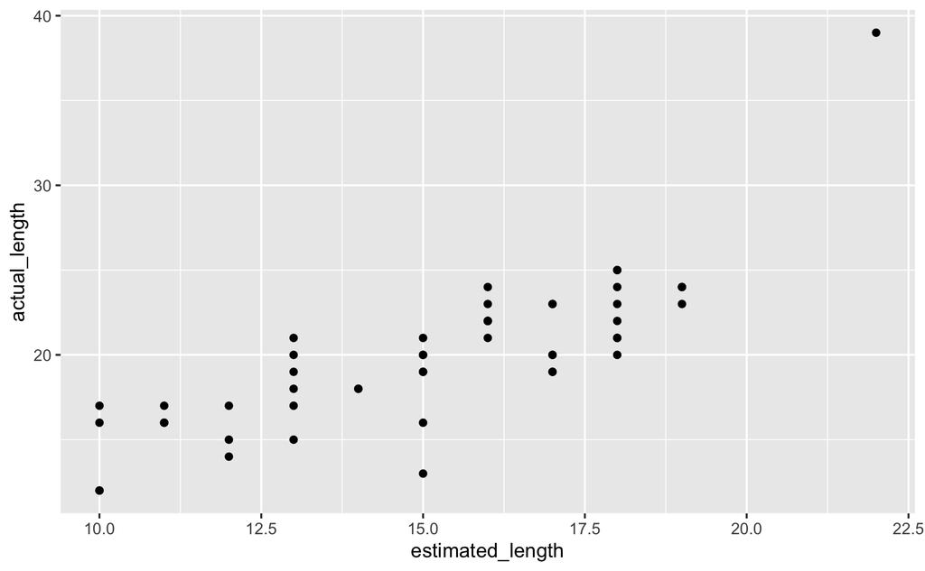

# Calculate the correlation coefficient of estimated_length and actual_length and interpret the value you obtain.

| r |
| --- |
| 0.8046597 |

An correlation coefficient of 0.8 indicates strong positive correlation. As estimatedtime increases, actual time increases.

# Perform a simple linear regression using actual_length as the dependent variable, and estimated_length as the independent variable. Save the model object to a variable.

```r
job_length %>%
  lm(formula = actual_length ~ estimated_length)
```

```
Call:
lm(formula = actual_length ~ estimated_length, data = .)

Coefficients:
     (Intercept)  estimated_length
           1.416             1.223
```

Interpret the regression coefficient of estimated_length (i.e. slope, gradient) you obtain from the model.

```r
job_model
```

```
Call:
lm(formula = actual_length ~ estimated_length, data = .)

Coefficients:
     (Intercept)  estimated_length
           1.416             1.223
```

We have a regression coefficient, or a slope of 1.223. This means for additional unit (guess days) of estimated job length, actual job length increases by 1.223 days.

How do you interpret the r2 value reported by the model?

| r.squared | adj.r.squared | sigma | statistic | p.value | df | logLik | AIC | BIC | deviance | df.residual | nobs |
| --- | --- | --- | --- | --- | --- | --- | --- | --- | --- | --- | --- |
| 0.6474772 | 0.640133 | 2.606163 | 88.16142 | 1.911284e-12 | 1 | -117.8203 | 241.6407 | 247.3767 | 326.0201 | 48 | 50 |

An r squared value is a measure of how well our line fits the data. An r squared value of 0.6 suggests that more than half of the variance in actual_length can be predicted from estimated_length.

# Is the relationship statistically significant? Remember, to assess this you need to check the p-value of the regression coefficient (or slope/gradient). But you should first check the regression diagnostic plots to see if the p-value will be reliable (don’t worry about any outlier points you see in the diagnostic plots, we’ll return to them in the extension).

H0: p_value = 0, Ha: p_value != 0 Alpha: 0.05

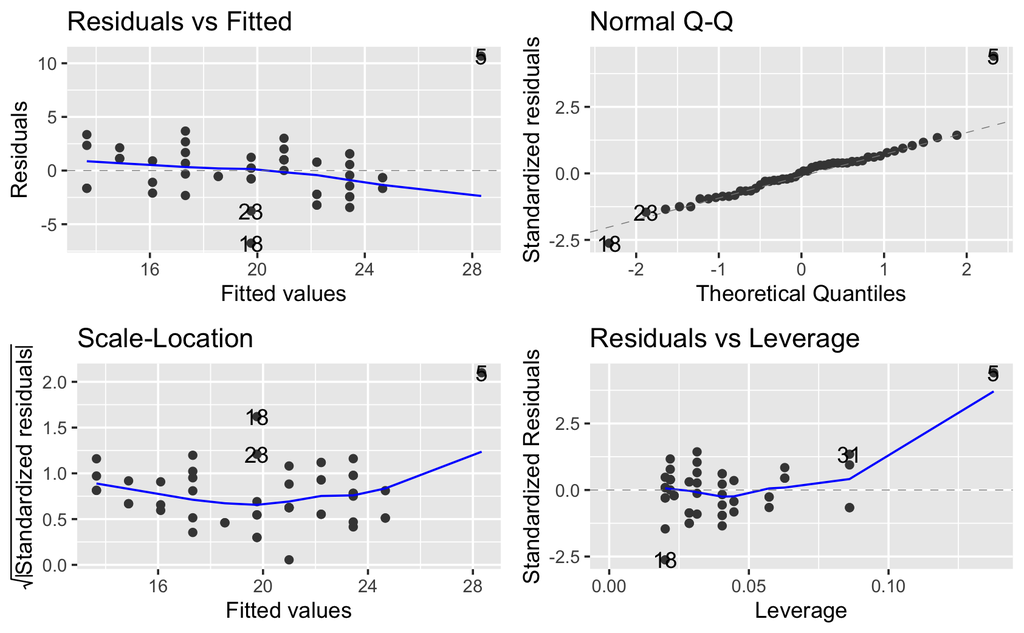

```r
autoplot(job_model)
```

```r
format(glance_job_model$p_value, scientific = FALSE)
```

```
                 value
"0.000000000001911284"
```

Our p value is less than our aplha or 0.05, so we can reject the null hypothesis and accept that there is a statistically significant relationship between estimated_length and actual_length. We can further test this hypothesis using the bootstrapping method.